# Netflix_titles

**Netflix Movies and TV Shows: Exploratory Data Analysis**

**Introduction** This project explores a dataset of movies and TV shows available on Netflix. The dataset contains information such as title, director, cast, release year, country of origin, rating, duration, and the date the content was added to Netflix. The goal is to uncover insights about the type of content Netflix hosts, how it has evolved over time, and what patterns emerge in terms of genre, country, and release trends.

By cleaning and analyzing this data using Python libraries such as pandas, matplotlib, and seaborn, we aim to answer questions like:

How much content is added each year?

What’s the balance between Movies and TV Shows?

Which countries and genres are most represented?

Dataset Source Kaggle.com

Libraries used | Library | Purpose | | ------------------------- | ----------------------------------------------------------- | | **pandas** | Data loading, cleaning, transformation, and analysis | | **numpy** | Numeric operations (used indirectly via pandas) | | **matplotlib** | Basic plotting and chart customization | | **seaborn** | High-level data visualization (e.g., bar plots, line plots) | | **wordcloud** | Generating word cloud visualizations from text data | | **datetime** *(optional)* | Working with dates (if not fully handled by pandas) |

**DATASET LOADING, CLEANING AND ANALYSIS**

```python
import pandas as pd
import datetime as dt
```

```python
netflix = pd.read_csv('netflix_titles.csv', index_col = 'show_id')
netflix.head()
```

| show_id | type | title | director | cast | country | date_added | release_year | rating | duration | listed_in | description |
| --- | --- | --- | --- | --- | --- | --- | --- | --- | --- | --- | --- |
| s1 | Movie | Dick Johnson Is Dead | Kirsten Johnson | NaN | United States | September 25, 2021 | 2020 | PG-13 | 90 min | Documentaries | As her father nears the end of his life, filmm... |
| s2 | TV Show | Blood & Water | NaN | Ama Qamata, Khosi Ngema, Gail Mabalane, Thaban... | South Africa | September 24, 2021 | 2021 | TV-MA | 2 Seasons | International TV Shows, TV Dramas, TV Mysteries | After crossing paths at a party, a Cape Town t... |
| s3 | TV Show | Ganglands | Julien Leclercq | Sami Bouajila, Tracy Gotoas, Samuel Jouy, Nabi... | NaN | September 24, 2021 | 2021 | TV-MA | 1 Season | Crime TV Shows, International TV Shows, TV Act... | To protect his family from a powerful drug lor... |
| s4 | TV Show | Jailbirds New Orleans | NaN | NaN | NaN | September 24, 2021 | 2021 | TV-MA | 1 Season | Docuseries, Reality TV | Feuds, flirtations and toilet talk go down amo... |
| s5 | TV Show | Kota Factory | NaN | Mayur More, Jitendra Kumar, Ranjan Raj, Alam K... | India | September 24, 2021 | 2021 | TV-MA | 2 Seasons | International TV Shows, Romantic TV Shows, TV ... | In a city of coaching centers known to train I... |

**Understanding the Shape of the Dataset**

```python
netflix.info()
```

```
<class 'pandas.core.frame.DataFrame'>
Index: 8807 entries, s1 to s8807
Data columns (total 11 columns):
 #   Column        Non-Null Count  Dtype
---  ------        --------------  -----
 0   type          8807 non-null   object
 1   title         8807 non-null   object
 2   director      6173 non-null   object
 3   cast          7982 non-null   object
 4   country       7976 non-null   object
 5   date_added    8797 non-null   object
 6   release_year  8807 non-null   int64
 7   rating        8803 non-null   object
 8   duration      8804 non-null   object
 9   listed_in     8807 non-null   object
 10  description   8807 non-null   object
dtypes: int64(1), object(10)
memory usage: 825.7+ KB
```

```python
print('Shape of the dataset:',netflix.shape)
```

```
Shape of the dataset: (8807, 11)
```

```python
print('\nColumn names\n', netflix.columns)
```

```
Column names
 Index(['type', 'title', 'director', 'cast', 'country', 'date_added',
       'release_year', 'rating', 'duration', 'listed_in', 'description'],
      dtype='object')
```

```python
netflix.isnull().sum()
```

```
type               0
title              0
director        2634
cast             825
country          831
date_added        10
release_year       0
rating             4
duration           3
listed_in          0
description        0
dtype: int64
```

**Cleaning Missing Values**

Filling missing Values in 'Director' and 'Country' columns with 'Unknown'

```python
netflix['director'] = netflix['director'].fillna('Unknown')
```

```python
netflix['country'] = netflix['country'].fillna('Unknown')
```

Filling missing values in 'date_added' column with the values in the 'release year'

```python
#checking null values in date_added column
netflix[netflix['date_added'].isnull()]
```

[output not shown]

```python
netflix['date_added'] = netflix['date_added'].fillna(pd.to_datetime(netflix['release_year'].astype(str)+'-01-01'))
```

```python
netflix['date_added'] = pd.to_datetime(netflix['date_added'], errors = 'coerce')
```

```python
netflix.dtypes
```

[output not shown]

Cleaning the 'duration' column

```python
#splitting 'duration' into two new columns
netflix[['duration_int','durtion_type']] = netflix['duration'].str.split(' ', expand=True)
```

```python
netflix['duration_int'] = pd.to_numeric(netflix['duration_int'])
```

```python
netflix.dtypes
```

[output not shown]

```python
netflix.drop(columns='duration', axis=1, inplace=True)
netflix
```

| show_id | type | title | director | cast | country | date_added | release_year | rating | listed_in | description | duration_int | durtion_type |
| --- | --- | --- | --- | --- | --- | --- | --- | --- | --- | --- | --- | --- |
| s1 | Movie | Dick Johnson Is Dead | Kirsten Johnson | NaN | United States | 2021-09-25 | 2020 | PG-13 | Documentaries | As her father nears the end of his life, filmm... | 90.0 | min |
| s2 | TV Show | Blood & Water | Unknown | Ama Qamata, Khosi Ngema, Gail Mabalane, Thaban... | South Africa | 2021-09-24 | 2021 | TV-MA | International TV Shows, TV Dramas, TV Mysteries | After crossing paths at a party, a Cape Town t... | 2.0 | Seasons |
| s3 | TV Show | Ganglands | Julien Leclercq | Sami Bouajila, Tracy Gotoas, Samuel Jouy, Nabi... | Unknown | 2021-09-24 | 2021 | TV-MA | Crime TV Shows, International TV Shows, TV Act... | To protect his family from a powerful drug lor... | 1.0 | Season |
| s4 | TV Show | Jailbirds New Orleans | Unknown | NaN | Unknown | 2021-09-24 | 2021 | TV-MA | Docuseries, Reality TV | Feuds, flirtations and toilet talk go down amo... | 1.0 | Season |
| s5 | TV Show | Kota Factory | Unknown | Mayur More, Jitendra Kumar, Ranjan Raj, Alam K... | India | 2021-09-24 | 2021 | TV-MA | International TV Shows, Romantic TV Shows, TV ... | In a city of coaching centers known to train I... | 2.0 | Seasons |
| ... | ... | ... | ... | ... | ... | ... | ... | ... | ... | ... | ... | ... |
| s8803 | Movie | Zodiac | David Fincher | Mark Ruffalo, Jake Gyllenhaal, Robert Downey J... | United States | 2019-11-20 | 2007 | R | Cult Movies, Dramas, Thrillers | A political cartoonist, a crime reporter and a... | 158.0 | min |
| s8804 | TV Show | Zombie Dumb | Unknown | NaN | Unknown | 2019-07-01 | 2018 | TV-Y7 | Kids' TV, Korean TV Shows, TV Comedies | While living alone in a spooky town, a young g... | 2.0 | Seasons |
| s8805 | Movie | Zombieland | Ruben Fleischer | Jesse Eisenberg, Woody Harrelson, Emma Stone, ... | United States | 2019-11-01 | 2009 | R | Comedies, Horror Movies | Looking to survive in a world taken over by zo... | 88.0 | min |
| s8806 | Movie | Zoom | Peter Hewitt | Tim Allen, Courteney Cox, Chevy Chase, Kate Ma... | United States | 2020-01-11 | 2006 | PG | Children & Family Movies, Comedies | Dragged from civilian life, a former superhero... | 88.0 | min |
| s8807 | Movie | Zubaan | Mozez Singh | Vicky Kaushal, Sarah-Jane Dias, Raaghav Chanan... | India | 2019-03-02 | 2015 | TV-14 | Dramas, International Movies, Music & Musicals | A scrappy but poor boy worms his way into a ty... | 111.0 | min |

8807 rows × 12 columns

**VISUALIZATION**

**Number of Movies vs TV shows**

```python
import matplotlib.pyplot as plt
import seaborn as sns
```

```python
sns.set(style = 'whitegrid')
```

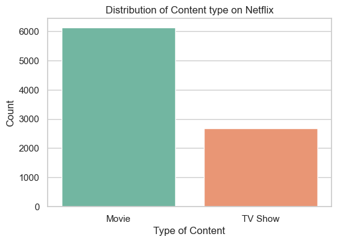

```python
plt.figure(figsize = (6, 4))
sns.countplot(data=netflix, x='type', palette = 'Set2')
plt.title('Distribution of Content type on Netflix')
plt.xlabel('Type of Content')
plt.ylabel('Count')
plt.show()
```

**Titles added per year**

```python
#Extracting the year from the 'date_added' column
netflix['year_added'] = netflix['date_added'].dt.year
```

```python
#counting titles per year
titles_per_year = netflix['year_added'].value_counts().sort_index()
```

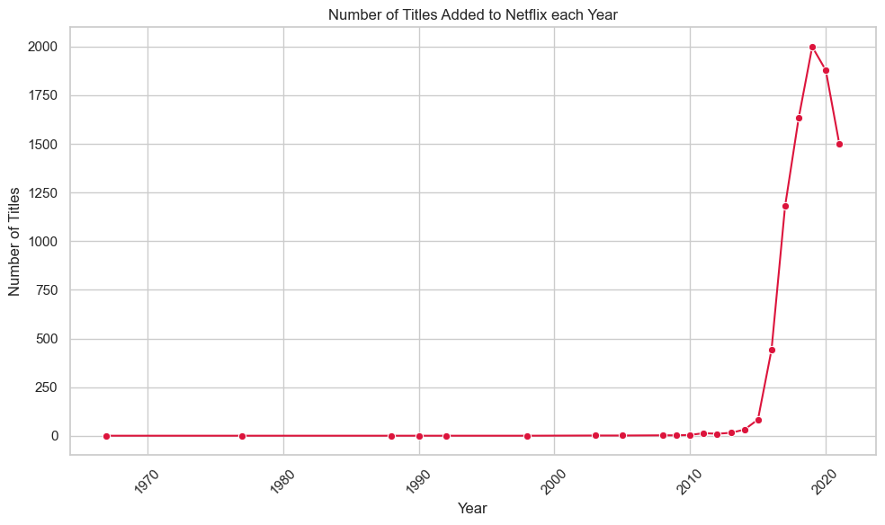

```python
plt.figure(figsize = (10,6))
sns.lineplot(x=titles_per_year.index, y=titles_per_year.values, marker='o', color='crimson')
plt.title('Number of Titles Added to Netflix each Year')
plt.xlabel('Year')
plt.ylabel('Number of Titles')
plt.xticks(rotation = 45)
plt.grid(True)
plt.tight_layout()
plt.show()
```

**Content Type added per Year**

```python
year_type_counts = netflix.groupby(['year_added','type']).size().reset_index(name='count')
```

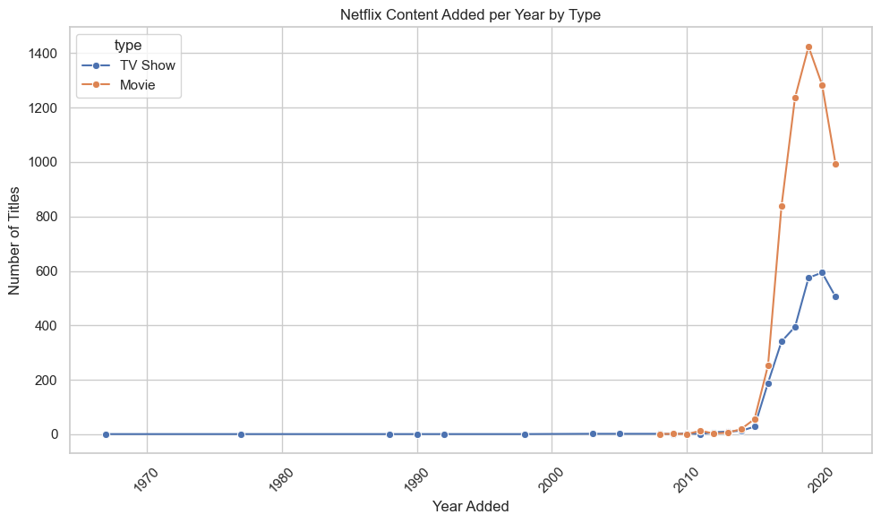

```python
plt.figure(figsize=(10,6))
sns.lineplot(data=year_type_counts, x='year_added', y='count', hue='type', marker='o')
plt.title('Netflix Content Added per Year by Type')
plt.xlabel('Year Added')
plt.ylabel('Number of Titles')
plt.xticks(rotation=45)
plt.grid(True)
plt.tight_layout()
plt.show()
```

During the pandemic Netflix focus was mainly on adding movies rather than TV shows

**Top Countries on Netflix**

```python
#dropping 'Unknown' values
country_data = netflix[netflix['country'] != 'Unknown'].copy()
```

```python
#splitting values where two or more countries are in the cell
country_data ['country'] = country_data['country'].str.split(', ')
country_exploded = country_data.explode('country')
```

```python
top_countries = country_exploded['country'].value_counts().head(10)
top_countries
```

```
country
United States     3689
India             1046
United Kingdom     804
Canada             445
France             393
Japan              318
Spain              232
South Korea        231
Germany            226
Mexico             169
Name: count, dtype: int64
```

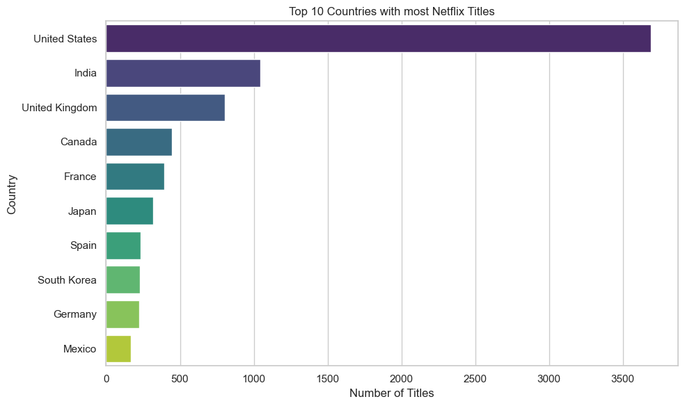

```python
plt.figure(figsize=(10,6))
sns.barplot(x=top_countries.values, y=top_countries.index, palette = 'viridis')
plt.title('Top 10 Countries with most Netflix Titles')
plt.xlabel('Number of Titles')
plt.ylabel('Country')
plt.tight_layout()
plt.show()
```

**Most Common Genres on Netflix**

```python
#splitting genres
genre_data = netflix.copy()
genre_data['genre'] = genre_data['listed_in'].str.split(', ')
genre_exploded = genre_data.explode('genre')
```

```python
top_genres = genre_exploded['genre'].value_counts().head(10)
top_genres
```

```
genre
International Movies        2752
Dramas                      2427
Comedies                    1674
International TV Shows      1351
Documentaries                869
Action & Adventure           859
TV Dramas                    763
Independent Movies           756
Children & Family Movies     641
Romantic Movies              616
Name: count, dtype: int64
```

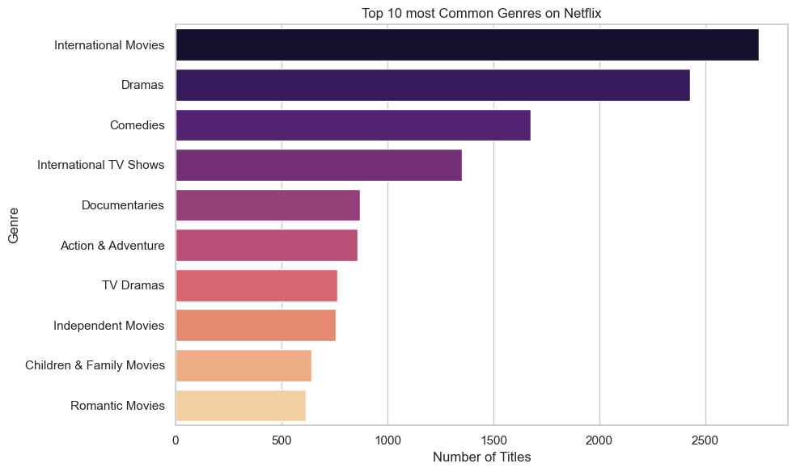

```python
plt.figure(figsize = (10,6))
sns.barplot(x=top_genres.values, y=top_genres.index, palette = 'magma')
plt.title('Top 10 most Common Genres on Netflix')
plt.xlabel('Number of Titles')
plt.ylabel('Genre')
plt.tight_layout()
plt.show()
```

**Text Analysis on Titles and Descriptions**

```python
pip install wordcloud
```

```
Downloading wordcloud-1.9.4-cp312-cp312-win_amd64.whl (301 kB)
```

```python
from wordcloud import WordCloud, STOPWORDS
import matplotlib.pyplot as plt
```

```python
text = ' '.join(netflix['description'].dropna().tolist())
```

```python
stopwords = set(STOPWORDS)
```

```python
wordcloud = WordCloud(stopwords = stopwords,
                      background_color='white',
                      max_words=100,
                      width=800,
                      height=400).generate(text)
```

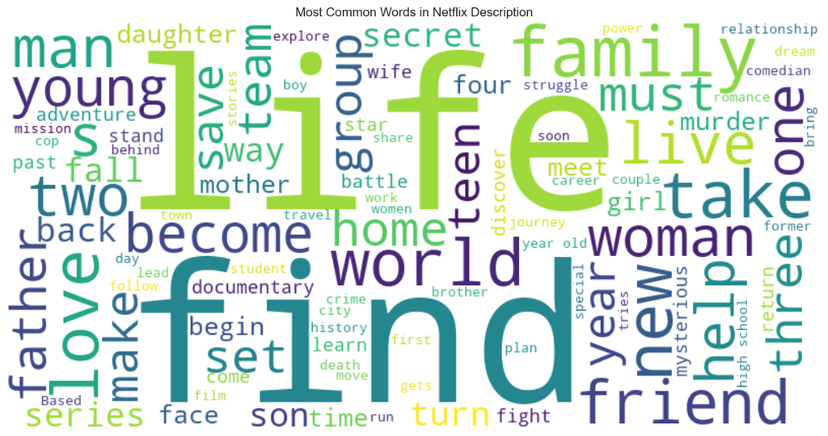

```python
plt.figure(figsize=(12,6))
plt.imshow(wordcloud, interpolation='bilinear')
plt.axis('off')
plt.title('Most Common Words in Netflix Description')
plt.tight_layout()
plt.show()
```

**Final Look of the Dataset**

```python
netflix.index = netflix.index.str.title()
netflix.columns = netflix.columns.str.title()
netflix
```

| show_id | Type | Title | Director | Cast | Country | Date_Added | Release_Year | Rating | Listed_In | Description | Duration_Int | Durtion_Type | Year_Added |
| --- | --- | --- | --- | --- | --- | --- | --- | --- | --- | --- | --- | --- | --- |
| S1 | Movie | Dick Johnson Is Dead | Kirsten Johnson | NaN | United States | 2021-09-25 | 2020 | PG-13 | Documentaries | As her father nears the end of his life, filmm... | 90.0 | min | 2021 |
| S2 | TV Show | Blood & Water | Unknown | Ama Qamata, Khosi Ngema, Gail Mabalane, Thaban... | South Africa | 2021-09-24 | 2021 | TV-MA | International TV Shows, TV Dramas, TV Mysteries | After crossing paths at a party, a Cape Town t... | 2.0 | Seasons | 2021 |
| S3 | TV Show | Ganglands | Julien Leclercq | Sami Bouajila, Tracy Gotoas, Samuel Jouy, Nabi... | Unknown | 2021-09-24 | 2021 | TV-MA | Crime TV Shows, International TV Shows, TV Act... | To protect his family from a powerful drug lor... | 1.0 | Season | 2021 |
| S4 | TV Show | Jailbirds New Orleans | Unknown | NaN | Unknown | 2021-09-24 | 2021 | TV-MA | Docuseries, Reality TV | Feuds, flirtations and toilet talk go down amo... | 1.0 | Season | 2021 |
| S5 | TV Show | Kota Factory | Unknown | Mayur More, Jitendra Kumar, Ranjan Raj, Alam K... | India | 2021-09-24 | 2021 | TV-MA | International TV Shows, Romantic TV Shows, TV ... | In a city of coaching centers known to train I... | 2.0 | Seasons | 2021 |
| ... | ... | ... | ... | ... | ... | ... | ... | ... | ... | ... | ... | ... | ... |
| S8803 | Movie | Zodiac | David Fincher | Mark Ruffalo, Jake Gyllenhaal, Robert Downey J... | United States | 2019-11-20 | 2007 | R | Cult Movies, Dramas, Thrillers | A political cartoonist, a crime reporter and a... | 158.0 | min | 2019 |
| S8804 | TV Show | Zombie Dumb | Unknown | NaN | Unknown | 2019-07-01 | 2018 | TV-Y7 | Kids' TV, Korean TV Shows, TV Comedies | While living alone in a spooky town, a young g... | 2.0 | Seasons | 2019 |
| S8805 | Movie | Zombieland | Ruben Fleischer | Jesse Eisenberg, Woody Harrelson, Emma Stone, ... | United States | 2019-11-01 | 2009 | R | Comedies, Horror Movies | Looking to survive in a world taken over by zo... | 88.0 | min | 2019 |
| S8806 | Movie | Zoom | Peter Hewitt | Tim Allen, Courteney Cox, Chevy Chase, Kate Ma... | United States | 2020-01-11 | 2006 | PG | Children & Family Movies, Comedies | Dragged from civilian life, a former superhero... | 88.0 | min | 2020 |
| S8807 | Movie | Zubaan | Mozez Singh | Vicky Kaushal, Sarah-Jane Dias, Raaghav Chanan... | India | 2019-03-02 | 2015 | TV-14 | Dramas, International Movies, Music & Musicals | A scrappy but poor boy worms his way into a ty... | 111.0 | min | 2019 |

8807 rows × 13 columns

**Insights**

Top Countries: The United States leads in content production, followed by India, the United Kingdom, and other global contributors.

Frequent Themes: From the text descriptions, words like life, love, family, and murder frequently appear, revealing common narrative elements.

Diverse Content: Netflix features content from a wide range of countries and genres, appealing to a global audience.

**Conclusion**

This project showcases how Python can be used for real-world data analysis tasks in media and entertainment. Using pandas, seaborn, and wordcloud, we extracted meaningful insights from Netflix’s catalog, such as content trends, popular genres, and regional diversity.

Such analysis is not only useful for understanding platform strategy but can also support personalized recommendations, market research, and content planning.

In a professional context, this kind of exploration demonstrates a data analyst's ability to clean, visualize, and interpret large datasets.

**Credits and Extras**

Dataset: Provided by Kaggle – Netflix Titles Dataset

Tools Used: Python, Jupyter Notebook, pandas, matplotlib, seaborn, wordcloud